# Stripe Recurring Topup Fee Change 1% -> 3%

Dani Mermelstein

2021-01-06

# TL;DR

The objective of this analysis is to see whether our fee change on October 23, 2020 (from 1% to 3% on recurring Stripe topup transactions) affected customer funding behavior. The overall answer is it most likely did not, which implies there this funding method is relatively price inelastic.

- There’s no confirmed change to the Signup -> second deposit rate
  - However, directionally it appears users are now more likely to make a second deposit
- There was no significant change to total deposits within 14 days of KYC Complete
  - It’s possible after the fee change we’re seeing smaller topup amounts per txn, but more transactions per user
- Lapse rates might have improved
  - There aren’t enough users for statistical significance, and due to the large amount of time required between cohorts in this part of the pre/post analysis additional external factors could influence lapse rates
- Recurring TopUp transactions are ~2 points less risky now than recurring txns before the fee change

## Takeaways and Recommendation

**THIS WAS NOT AN A/B TEST**. All outputs should be taken with a grain of salt (see the Caveats section).

We project we’re currently making about $2,500/month on Stripe topup right now, counting both first and recurring deposits. There’s an estimated margin of $0.40 per transaction, making for an ~16% total margin. Combined with the fact that we don’t see a change in user behavior when it comes to funding or total amounts funded (despite low numbers in the analysis) we can likely leave fee pricing where it is and move on to optimizing other funding methods. For more detail on the dollar cost and revenue of running this feature so far, see [this document](https://docs.google.com/spreadsheets/d/1vq9xc7_Il1YzFsoIqAvqCvAWM-s7Upar/edit#gid=1153847189).

## Caveats

All analysis here was done as a pre/post analysis. The lapse rate analysis was underpowered because not enough time has passed since the fee change. Whenever we do a pre/post analysis we risk being influenced by a variety of external factors, including but not limited to:

- changes in market sentiment
- differences between cohorts
- changes to the unemployment rate (unfortunately a major factor this year)
- changes in fraudulent user behavior (we filtered out all confirmed fraud cases, but we might not have caught all of it)
- marketing/acquisition efforts that happened at different periods
- etc…

# Analysis

## Incremental Funding Rate (2nd Txn)

Data is within 14 days of KYC Complete for a 7 day cohort

**These results are NOT significant**

| category | min_kyc | max_kyc |
| --- | --- | --- |
| pre | 2020-10-01 20:04:23 | 2020-10-08 19:30:23 |
| post | 2020-10-22 20:06:25 | 2020-10-29 19:55:25 |

| Variants | Users | Outcomes | Funding.Rate |
| --- | --- | --- | --- |
| pre_launch | 486 | 52 | 0.1069959 |
| post_launch | 502 | 70 | 0.1394422 |

### 90% Confidence Interval:

```
##          5%         95%
## -0.01637453  0.72351525
```

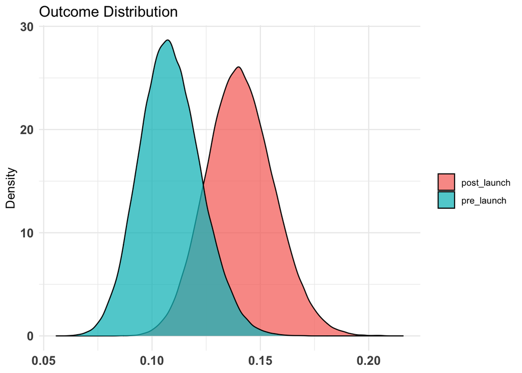

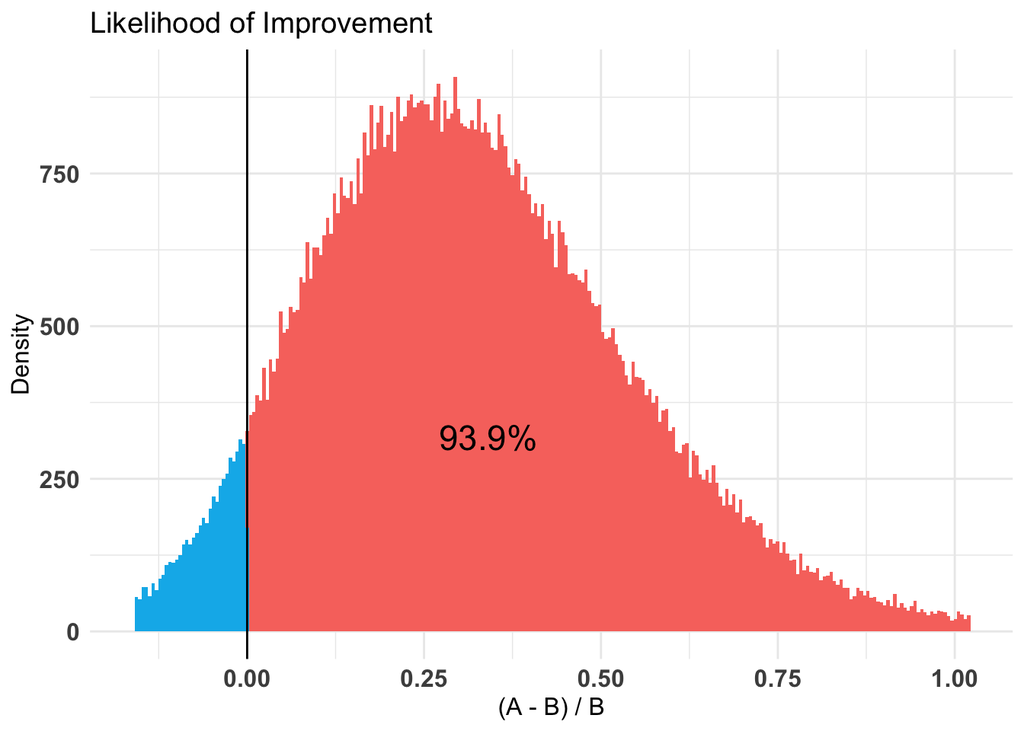

## Stripe Radar Risk Scores

for all recurring topup txns between 2020-10-09 and 2020-11-06

Differences in average risk scores for recurring topups now vs before the fee change are statistically significant

| category | avg_risk_score | users | txns |
| --- | --- | --- | --- |
| post | 14.61101 | 994 | 2234 |
| pre | 16.54500 | 741 | 1611 |

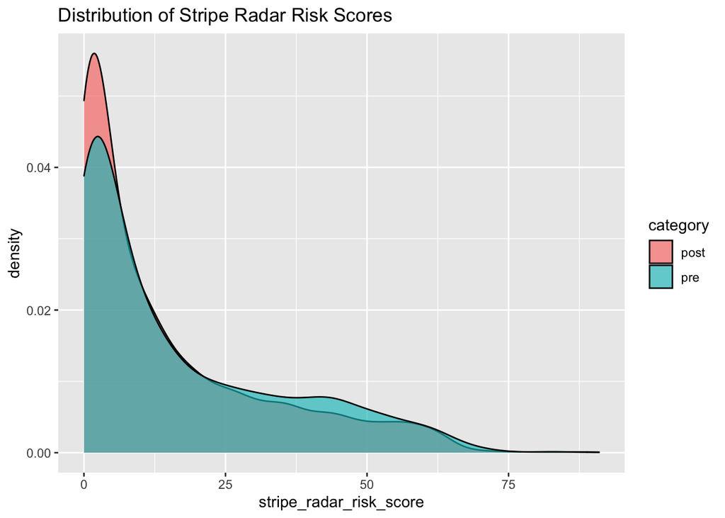

## Funding Amounts

Data is within 14 days of KYC Complete for a 7 day cohort

| category | min_kyc | max_kyc |
| --- | --- | --- |
| pre | 2020-10-01 20:04:23 | 2020-10-08 19:30:23 |
| post | 2020-10-22 20:06:25 | 2020-10-29 19:55:25 |

### Overall Funding

Differences in total funding amounts per user from before to after the fee change do NOT appear to be statistically significant

| category | med_total_amount_per_user | med_deposit_cnt | users |
| --- | --- | --- | --- |
| post | 140 | 5 | 117 |
| pre | 150 | 5 | 105 |

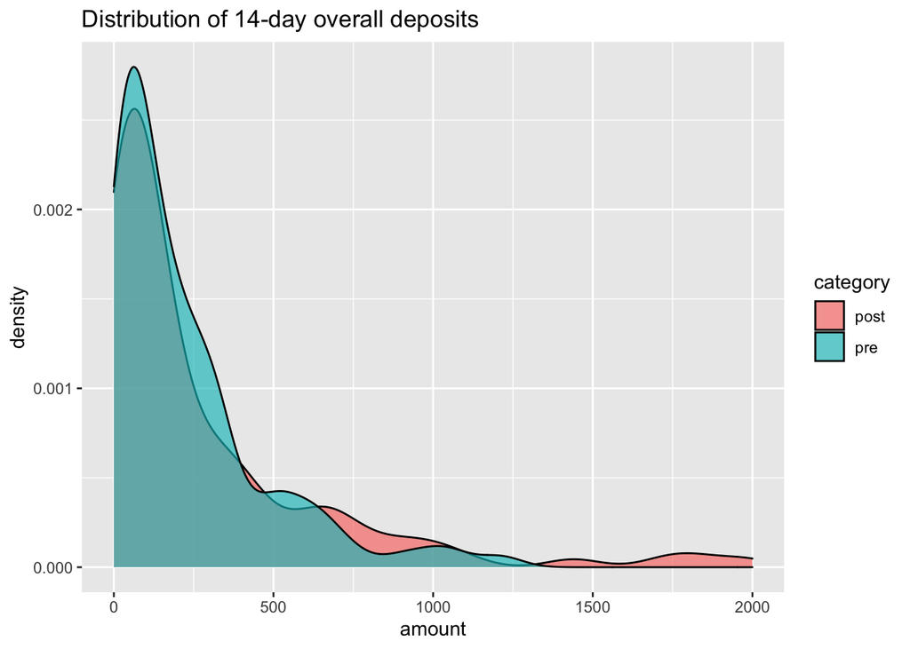

### Topup Users Only

Differences in total funding amounts per user from before to after the fee change do NOT appear to be statistically significant

| category | med_total_topup_amount_per_user | med_deposit_cnt | users |
| --- | --- | --- | --- |
| post | 94 | 4 | 44 |
| pre | 150 | 3 | 32 |

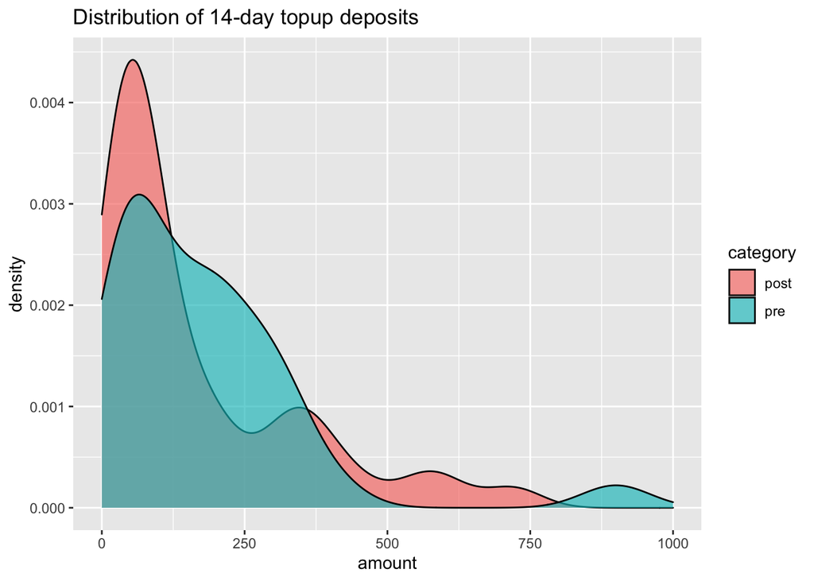

## Lapse Rates

Looking at 8-week lapse rates for a 2-week cohort of users pre/post the fee change on October 23

**These results are NOT significant**

| category | mau_group | users | total | rate |
| --- | --- | --- | --- | --- |
| post | full_lapse | 49 | 165 | 0.2969697 |
| post | reactivated | 6 | 165 | 0.0363636 |
| post | unbroken_mau | 110 | 165 | 0.6666667 |
| pre | full_lapse | 167 | 489 | 0.3415133 |
| pre | reactivated | 18 | 489 | 0.0368098 |
| pre | unbroken_mau | 304 | 489 | 0.6216769 |

| Variants | Users | Outcomes | Unbroken.MAU.Rate |
| --- | --- | --- | --- |
| pre_launch | 489 | 304 | 0.6216769 |
| post_launch | 165 | 110 | 0.6666667 |

### 90% Confidence Interval:

```
##         5%        95%
## -0.0430522  0.1875793
```

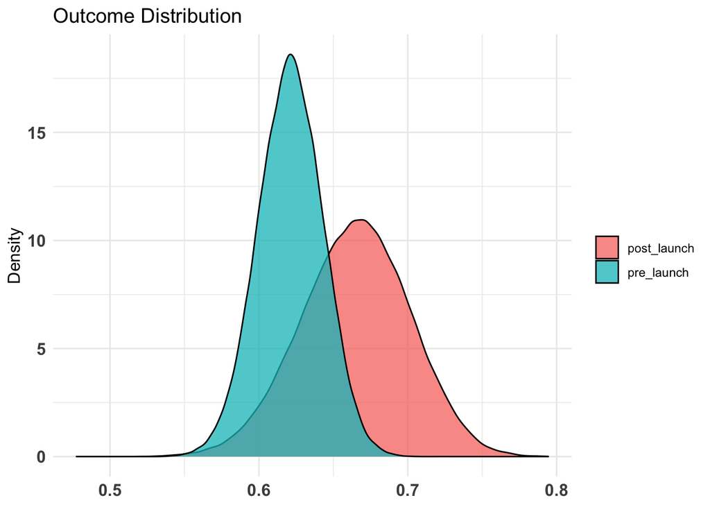

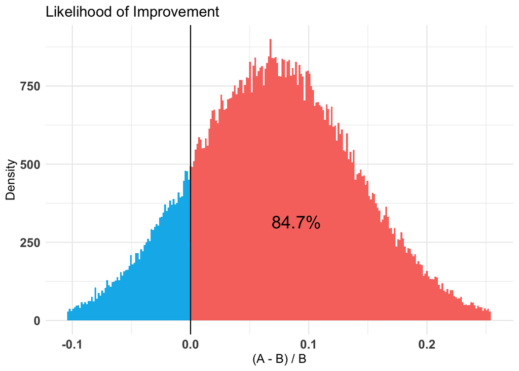